# Lab 1

Notice that `ggplot` gives a warning about missing variables (`hist` just silently removed them without telling you).

We can add more features to our `ggplot`, just like with basic R plotting commands.

```
## Warning: Removed 1493 rows containing non-finite values (`stat_bin()`).
```

```
## Warning: Removed 2 rows containing missing values (`geom_bar()`).
```

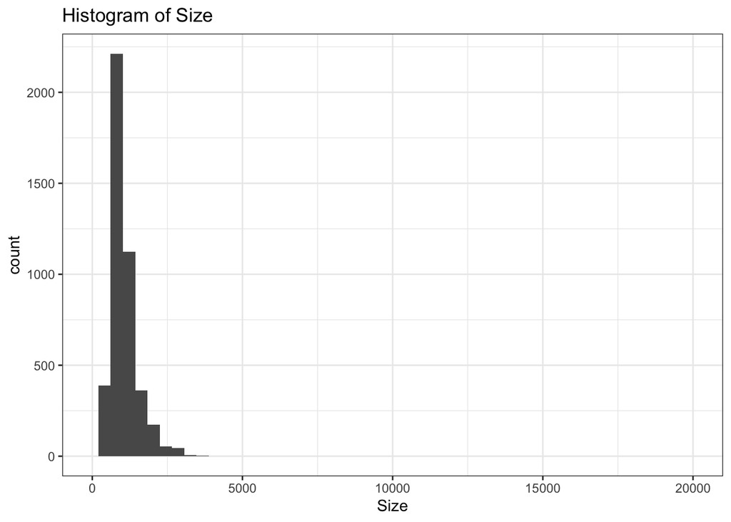

```r
# ggplot version
ggplot(data = craigslist) +
  geom_histogram(bins = 50, aes(x = size)) +
  labs(x = 'Size', title = 'Histogram of Size') + #provide axis, plot labels
  xlim(0,20000) + # zoom in
  theme_bw() #change to black and white, instead of grey background
```

`ggplot2` also makes it easy to make separate plots for subsets of the data (when those subsets are defined by a variable in your `data.frame`). These are called “facets” of the data

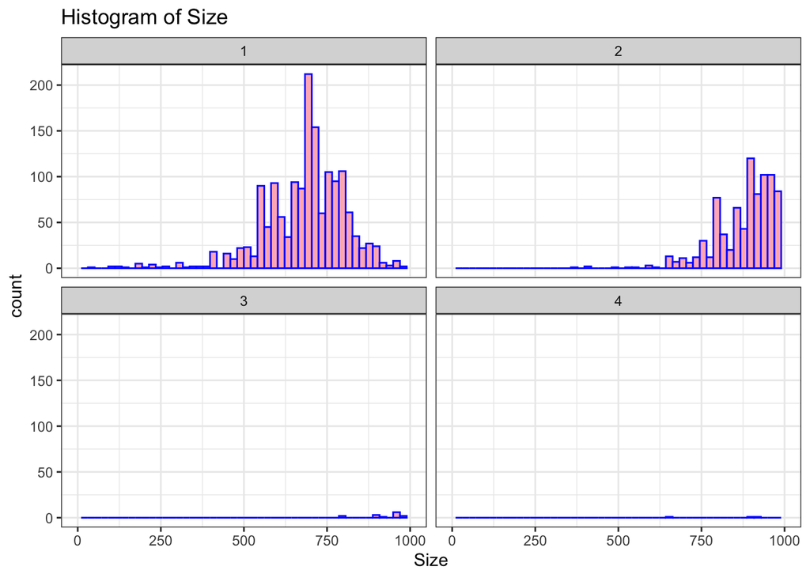

```r
# ggplot version
ggplot(data = craigslist) +
  geom_histogram(bins = 50, aes(x = size), fill="light pink", color = "blue") +
  labs(x = 'Size', title = 'Histogram of Size') + #provide axis, plot labels
  xlim(0,1000) + # zoom in
facet_wrap(~factor(brs))+
  theme_bw() #change to black and white, instead of grey background
```

We can also make density histograms of each group

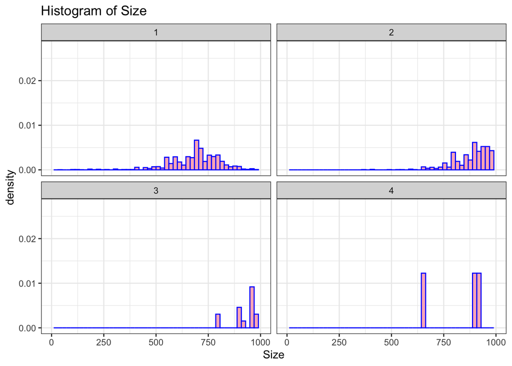

```r
# ggplot version
ggplot(data = craigslist) +
  geom_histogram(bins = 50, aes(x = size,..density..), fill="light pink", color = "blue") +
  labs(x = 'Size', title = 'Histogram of Size') + #provide axis, plot labels
  xlim(0,1000) + # zoom in
facet_wrap(~factor(brs))+
  theme_bw() #change to black and white, instead of grey background
```

## Boxplots

Here is our previous boxplot command,

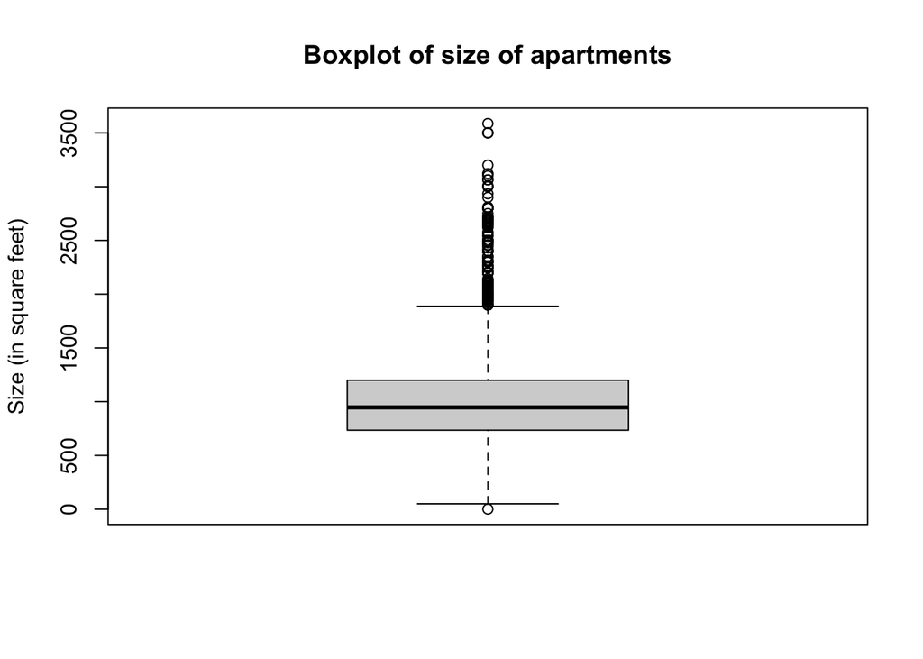

```r
boxplot(craigslist$size[craigslist$size<60000],
     main = "Boxplot of size of apartments",
     ylab="Size (in square feet)"
)
```

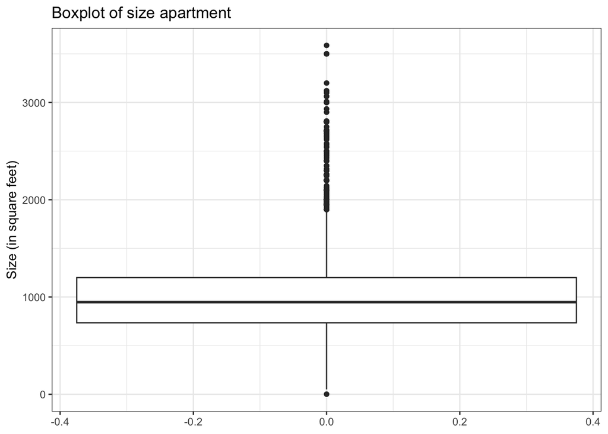

```r
ggplot(craigslist[craigslist$size<60000,]) +
  geom_boxplot(aes(y = size)) +
  labs(y = 'Size (in square feet)', title = 'Boxplot of size apartment') +
  theme_bw()
```

We don’t really want the x-axis markings, so we can do this:

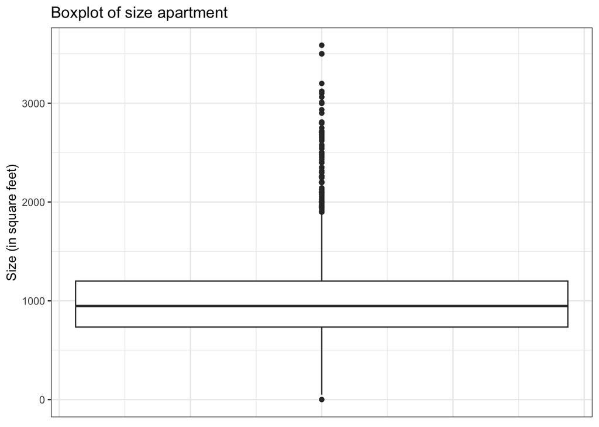

```r
ggplot(craigslist[craigslist$size<60000,]) +
  geom_boxplot(aes(y = size)) +
  labs(y = 'Size (in square feet)', title = 'Boxplot of size apartment') +
  theme_bw() + # theme_bw needs to be before theme
  theme(axis.ticks.x = element_blank(), axis.text.x = element_blank()) # remove x axis ticks and labels
```

If we want to compare different groups we previously had

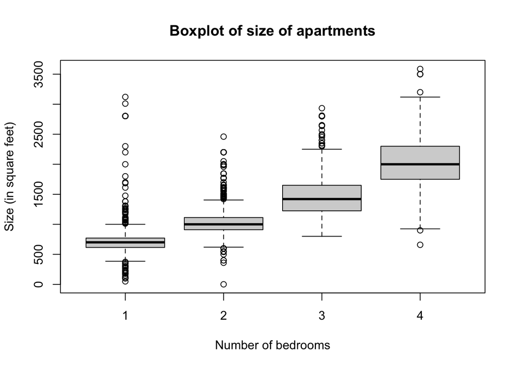

```r
boxplot(size ~brs , data=craigslist[craigslist$size<60000,],
     main = "Boxplot of size of apartments",
     ylab="Size (in square feet)",
     xlab="Number of bedrooms"
)
```

To do the same thing in `ggplot` we would define our `x` variable to be the variable that we want to separate them by. The variable we need to split them by needs to be a `factor`, and number of bedrooms is numeric, so we use the `factor` function to make it treat it as a factor.

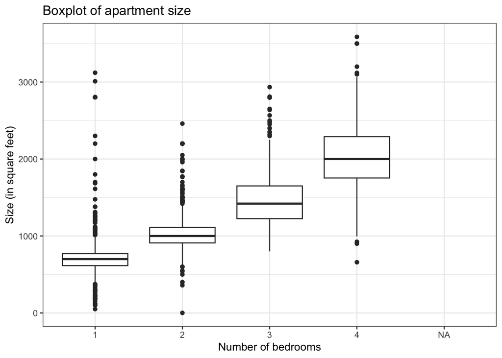

```r
ggplot(craigslist[craigslist$size<60000,]) +
  geom_boxplot(aes(x = factor(brs), y = size)) +
  labs(x = 'Number of bedrooms',
       y = 'Size (in square feet)',
       title = 'Boxplot of apartment size') +
  theme_bw()
```

## Scatterplots

`ggplot2` also makes scatter plots using `geom_point`.

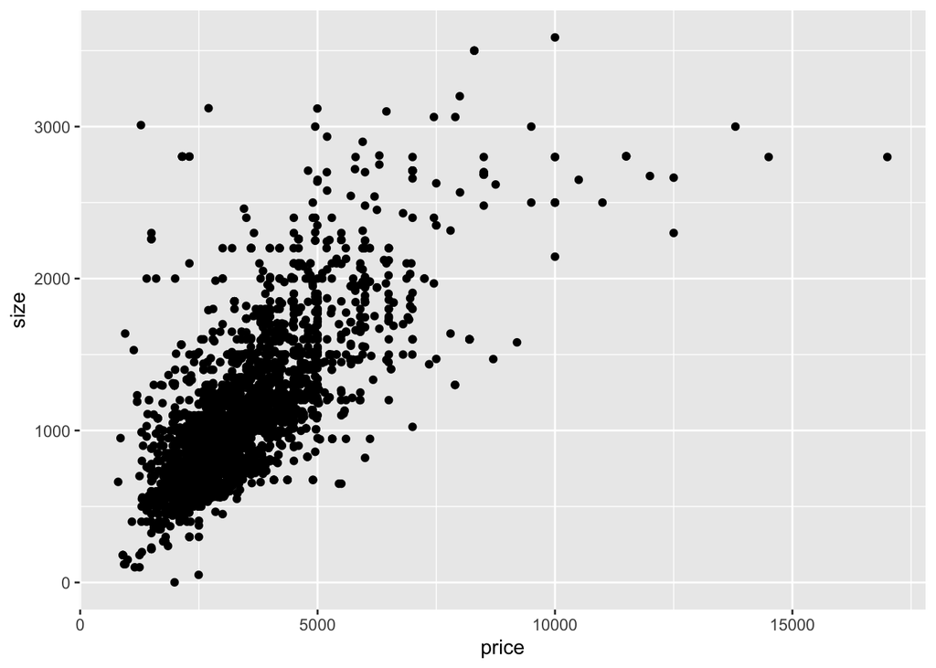

```r
ggplot(craigslist[craigslist$size<60000,]) + geom_point(aes(x=price,y=size))
```

We can easily color the points by number of bedrooms

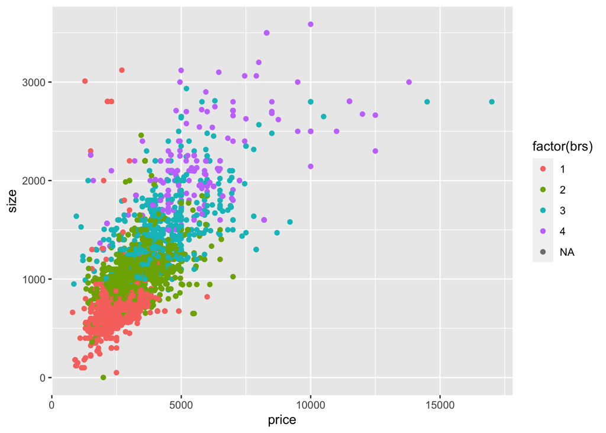

```r
ggplot(craigslist[craigslist$size<60000,]) + geom_point(aes(x=price,y=size, color=factor(brs)))
```

**Exercise 5.**

Make separate scatterplots of size vs price for each location; on each scatterplot color the points by the number of bedrooms, as above. Give a title to your plot and informative (non-default) x and y axis labels.

```r
# insert code here
```